# Predicting Survival of Intensive Care Unit Patients with Support Vector Machines

Authors

Josh Hollandsworth

Brad Lipson

Eric Miller

Published

October 10, 2023

# Introduction

Every day sensors and systems are capturing a virtual flood of data points and feeding those values into powerful artificial intelligence and machine learning systems to derive classifications and predict a myriad of outcomes. These systems help us do a broad spectrum of things from fraud detection to interactions with smart home systems. Given the number of data points that are present in the medical field, it is of no surprise that machine learning is increasingly being leveraged to elevate patient care.

For as long as most of us remember, our interactions with physicians have included the gathering of data points to help them detect illness and track progression of disease. Common data points are age, weight, height, temperature, blood pressure, list of any current symptoms and etc. Physicians then use their education and years of practice to provide diagnoses and help us live happy and healthy lives. But what if this was process could be supported with machine learning, and brought into a more critical care setting?

We can. Thanks to machine learning we can use data from the countless sensors and measurements taken by medical staff in Intensive Care Units (ICU) to predict the survivability of patients under care. This data can then help teams organize around certain cases to help ensure the best allotment of resources and highest attention to the most dire of cases. A method we will use in this report is through the construction of Support Vector Machines or SVM’s.

SVM’s are a machine learning methodology that uses supervised learning based on historic cases to help train models that can then be used on other cases. Models created by Support Vector Machines are used to create clusters of 2 distinct groups of data based on the creation of a maximally-marginal hyperplane.(Han and Pei 2012). A maximally-marginal hyperplane can be explained as a line that can be drawn between two clusters that separates their members with the greatest distance between members of each cluster that are their nearest.

While we did not find many cases of using support vector machines for ICU patient survival, the use of Support Vector Machines in medicine is not a novel approach. In “Using Support Vector Machines for Diabetes Mellitus Classification from Electronic Medical Records” by Adeoye the author leveraged electronic medical records to help classify individuals with and without diabetes. Meanwhile, Zhou et al where able to use Support Vector Machines to predict the prognosis of severe, acute myocardial infarction with 92% accuracy from electronic medical records(Zhou 2023)

While Support Vector Machines can be a great utility used to cluster and predict outcomes, their usage in Medicine is not without problems. One problem noted by Liu et al is that the sheer number of data points available can make it hard to find features (data points of importance) for use in model construction.(Liu June 2018) In fact Liu goes as far as describing the use of Principal Component Analysis to chose which features to include in model construction. Additionally, support vector machines work best when the data can be mapped linearly, however unlike other methodologies this is not a strict requirement. Should data not be easily linearly separable the use of a kernel function or kernel trick allows data to be mapped from one space to another for optimal construction of the maximally marginal hyperplane (Han and Pei 2012) (Mohan et al. 2020)

# Methods

Data Source

To build our model for predicting patient survivability, we are using data from the [Medical Information Mart for Intensive Care (MIMIC)](https://mimic.mit.edu). We are specifically targeting the MIMIC III data set. You can find more information about the MIMIC III dataset at https://mimic.mit.edu/docs/iii/ The data set itself is rather large so we have pre-processed the data slightly in order to generate a file of comma separated values rather than consume directly from their highly normalized format.

# Analysis and Results

## Data and Vizualisation

```r
library(gtsummary)

mimic_data_summary <- mimic_data %>% select(age,
gender,
hospital_expire_flag,
heartrate_mean,
sysbp_mean,
resprate_mean,
tempc_mean,
wbc_mean,
platelet_min,
creatinine_max,
lactate_mean) %>%
mutate(
  gender = case_when(gender == "M" ~ "male",
                     gender == "F" ~ "female",
                     TRUE ~ gender),
  survived = case_when(hospital_expire_flag == 1 ~ "Died",
                     hospital_expire_flag == 0 ~ "Survived")
) %>%
  tbl_summary(
    label = list(age ~ "Patient Age",
      gender ~ "Patient Sex",
      survived ~ "Patient Survived",
      heartrate_mean ~ "Heart Rate",
      sysbp_mean ~ "Systolic Blood Pressure",
      resprate_mean ~ "Respiration Rate",
      tempc_mean ~ "Body Temperature (c)",
      wbc_mean ~ "White Blood Cell Count",
      platelet_min ~"Platelet Count",
      creatinine_max ~"Creatinine Level",
      lactate_mean ~"Lactate Level"
      ),
     type = list(age ~ "continuous2",
      gender ~ "categorical",
      survived ~ "categorical",
      heartrate_mean ~ "continuous2",
      sysbp_mean ~ "continuous2",
      resprate_mean ~ "continuous2",
      tempc_mean ~ "continuous2",
      wbc_mean ~ "continuous2",
      platelet_min ~"continuous2",
      creatinine_max ~"continuous2",
      lactate_mean ~"continuous2"
      ),
      statistic = all_continuous() ~ c("{median} ({p25}, {p75})", "{min}, {max}"),
      include = c(
        "age",
        "gender",
        "heartrate_mean",
        "survived",
        "sysbp_mean",
        "resprate_mean",
        "tempc_mean",
        "wbc_mean",
        "platelet_min",
        "creatinine_max",
        "lactate_mean"
      )
  )



mimic_data_summary
```

| **Characteristic** | **N = 4,559**<sup>1</sup> |
| --- | --- |
| Patient Age |  |
| Median (IQR) | 67 (54, 80) |
| Range | 17, 91 |
| Patient Sex |  |
| female | 1,978 (43%) |
| male | 2,581 (57%) |
| Heart Rate |  |
| Median (IQR) | 88 (76, 100) |
| Range | 36, 155 |
| Patient Survived |  |
| Died | 741 (16%) |
| Survived | 3,818 (84%) |
| Systolic Blood Pressure |  |
| Median (IQR) | 114 (105, 126) |
| Range | 70, 195 |
| Unknown | 8 |
| Respiration Rate |  |
| Median (IQR) | 19.3 (16.8, 22.4) |
| Range | 9.5, 40.6 |
| Unknown | 1 |
| Body Temperature (c) |  |
| Median (IQR) | 36.82 (36.41, 37.31) |
| Range | 31.60, 40.10 |
| Unknown | 103 |
| White Blood Cell Count |  |
| Median (IQR) | 12 (8, 16) |
| Range | 0, 404 |
| Platelet Count |  |
| Median (IQR) | 178 (122, 246) |
| Range | 5, 1,297 |
| Unknown | 6 |
| Creatinine Level |  |
| Median (IQR) | 1.20 (0.90, 1.90) |
| Range | 0.10, 27.80 |
| Unknown | 2 |
| Lactate Level |  |
| Median (IQR) | 1.90 (1.35, 2.75) |
| Range | 0.30, 20.85 |

<sup>1</sup> n (%)

### Patient Demographics

#### Patient Age

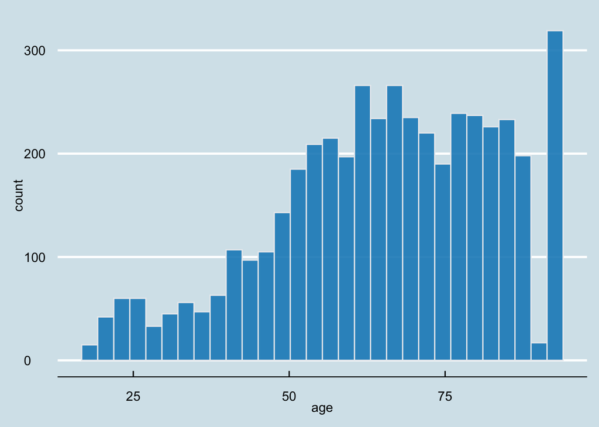

```r
ggplot(mimic_data, aes(x=age))+
  geom_histogram( color="#e9ecef", fill="#188bc2", alpha=0.9, position = 'identity') +
  theme_economist(base_family="ITC Officina Sans")
```

#### Patient Sex

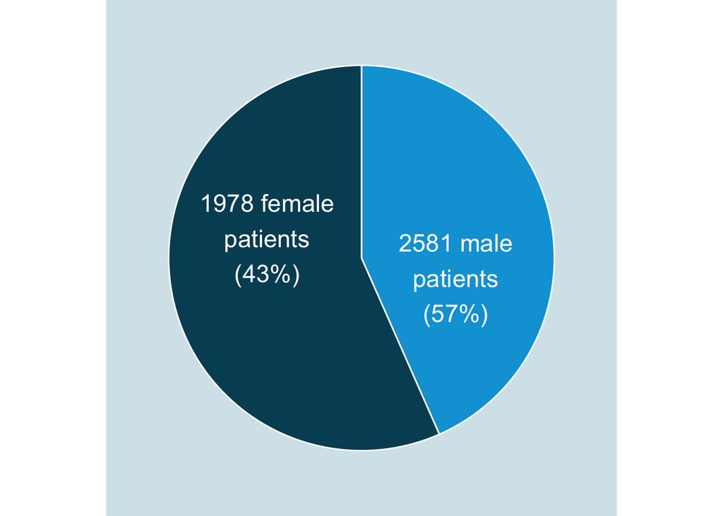

```r
mimic_data <- mimic_data %>% mutate(
  gender = case_when(gender == "M" ~ "male",
                     gender == "F" ~ "female",
                     TRUE ~ gender)
)

patient_sex_viz <- mimic_data %>%
  group_by(gender) %>%
  summarise(N = n()) %>%
  mutate(
    gender = as.factor(gender),
    pos = cumsum(N) - N/2,
    label = paste(N,  " ", gender, "\npatients\n(", 100*round(N/sum(N), 2), "%)", sep="")
  )

ggplot(patient_sex_viz, aes(x = "", y = N, fill = gender)) +
  geom_bar(stat = "identity", width=1, color="white", position = "stack") +
  coord_polar(theta = "y", direction = -1, clip = "off") +
  theme_economist(base_family="ITC Officina Sans") +
  theme(
    legend.position="none",
    line=element_blank(),
    axis.title.x=element_blank(),
    axis.text.x=element_blank(), #remove x axis labels
    axis.ticks.x=element_blank(), #remove x axis ticks
    axis.title.y=element_blank(),
    axis.text.y=element_blank(),  #remove y axis labels
    axis.ticks.y=element_blank()  #remove y axis ticks
  ) +
  geom_text(aes(y = pos, label = label), color = "white", size=6) +
  scale_fill_economist(labels=NULL)
```

#### Patient Survival

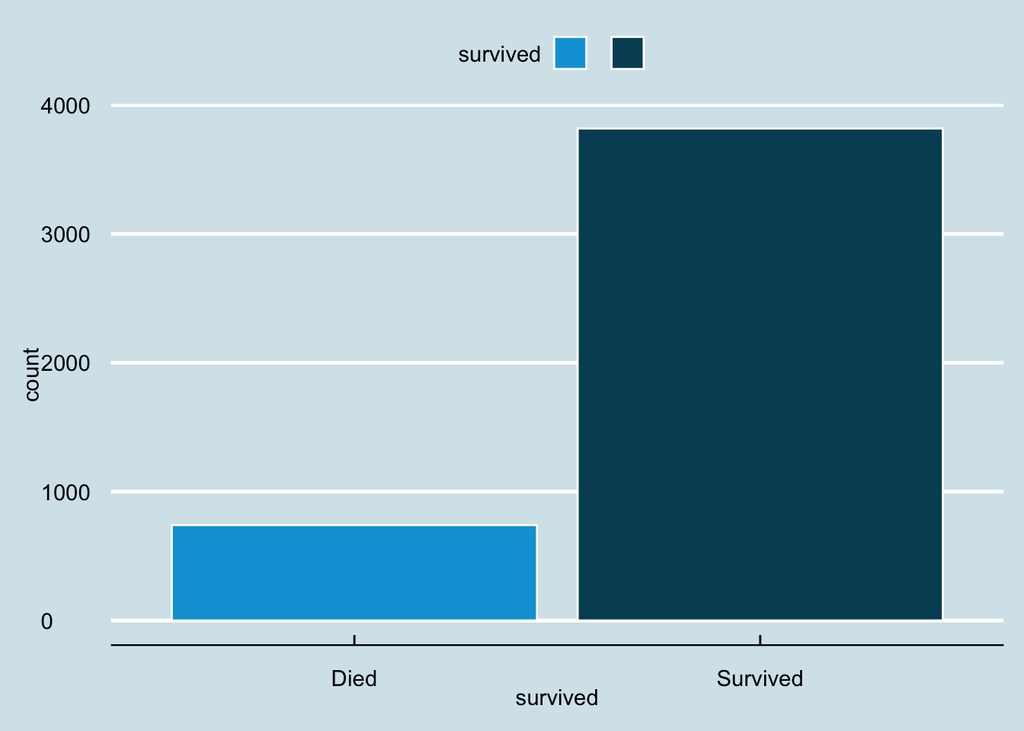

```r
mimic_data <- mimic_data %>% mutate(
  survived = case_when(hospital_expire_flag == 1 ~ "Died",
                     hospital_expire_flag == 0 ~ "Survived")
)

ggplot(mimic_data, aes(x = survived, fill=survived)) +
  geom_bar(color="white") +
  theme_economist(base_family="ITC Officina Sans") +
  scale_fill_economist(labels=NULL)
```

### Vital Signs

#### Heart rate

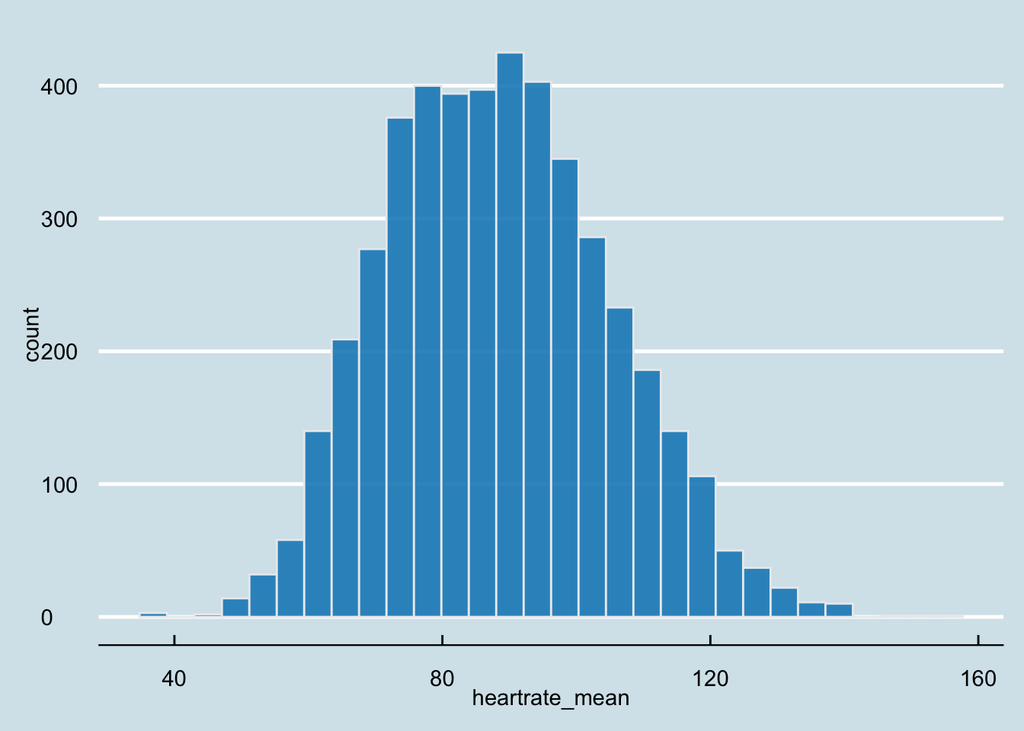

```r
ggplot(mimic_data, aes(x=heartrate_mean)) +
  geom_histogram( color="#e9ecef", fill="#188bc2", alpha=0.9, position = 'identity') +
  theme_economist(base_family="ITC Officina Sans")
```

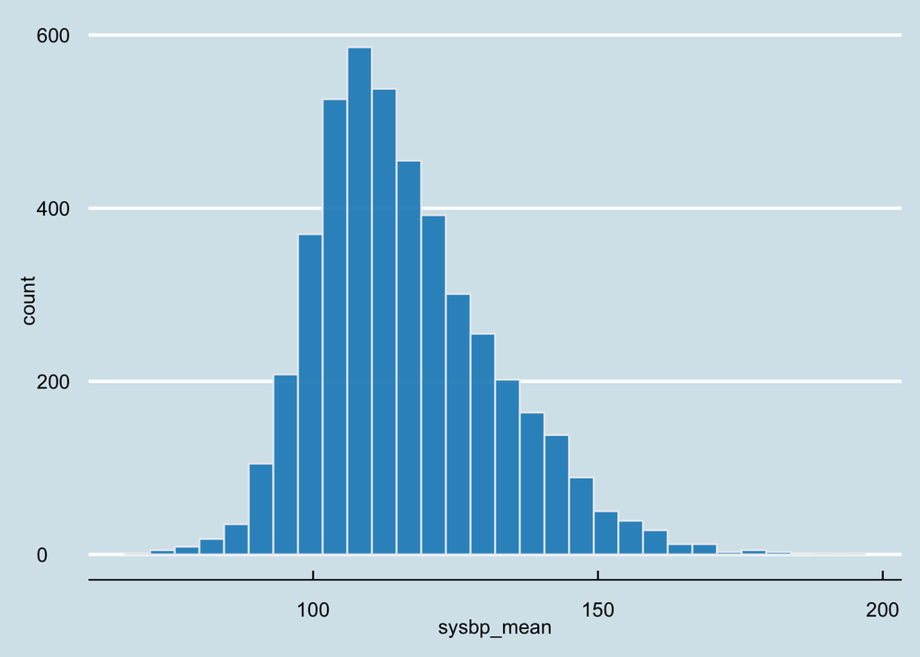

```r
ggplot(mimic_data, aes(x=sysbp_mean)) +
  geom_histogram( color="#e9ecef", fill="#188bc2", alpha=0.9, position = 'identity') +
  theme_economist(base_family="ITC Officina Sans")
```

#### Respiratory rate

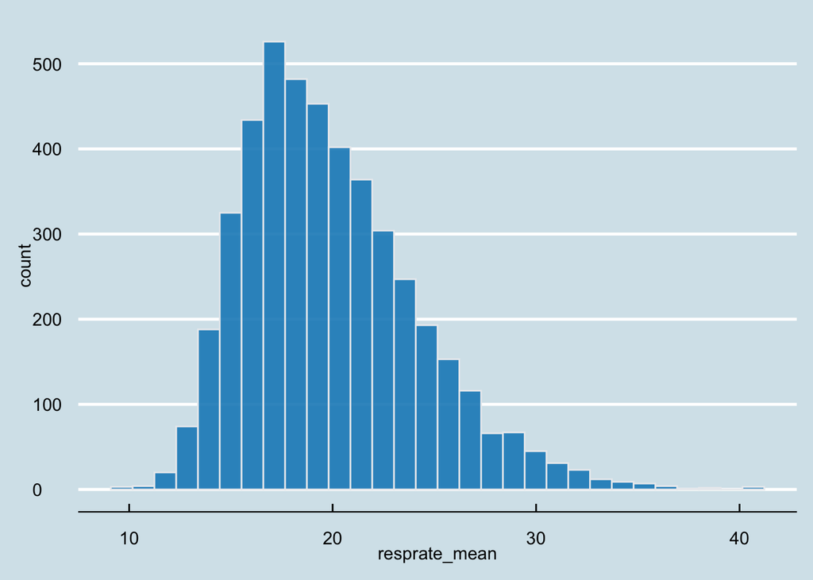

```r
ggplot(mimic_data, aes(x=resprate_mean)) +
  geom_histogram( color="#e9ecef", fill="#188bc2", alpha=0.9, position = 'identity') +
  theme_economist(base_family="ITC Officina Sans")
```

#### Temperature

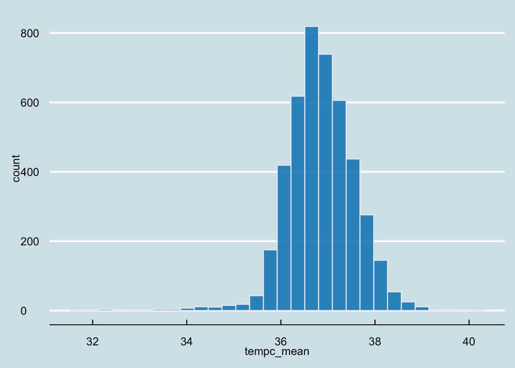

```r
ggplot(mimic_data, aes(x=tempc_mean)) +
  geom_histogram( color="#e9ecef", fill="#188bc2", alpha=0.9, position = 'identity') +
  theme_economist(base_family="ITC Officina Sans")
```

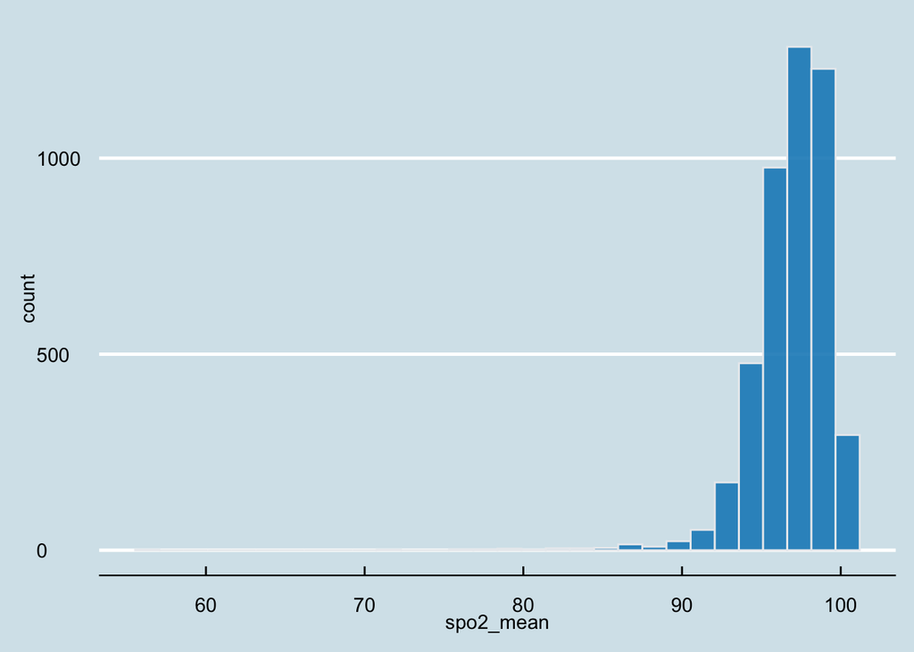

```r
ggplot(mimic_data, aes(x=spo2_mean)) +
  geom_histogram( color="#e9ecef", fill="#188bc2", alpha=0.9, position = 'identity') +
  theme_economist(base_family="ITC Officina Sans")
```

### Laboratory Values

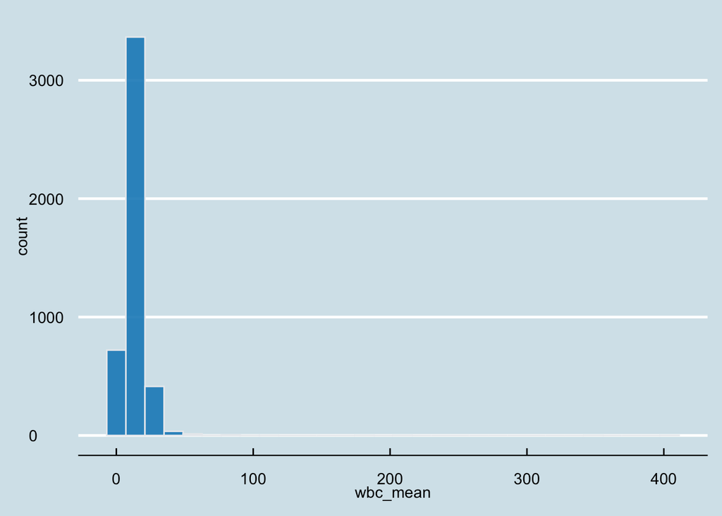

```r
ggplot(mimic_data, aes(x=wbc_mean)) +
  geom_histogram( color="#e9ecef", fill="#188bc2", alpha=0.9, position = 'identity') +
  theme_economist(base_family="ITC Officina Sans")
```

*NOT FOUND IN DATA*

*NOT FOUND IN DATA*

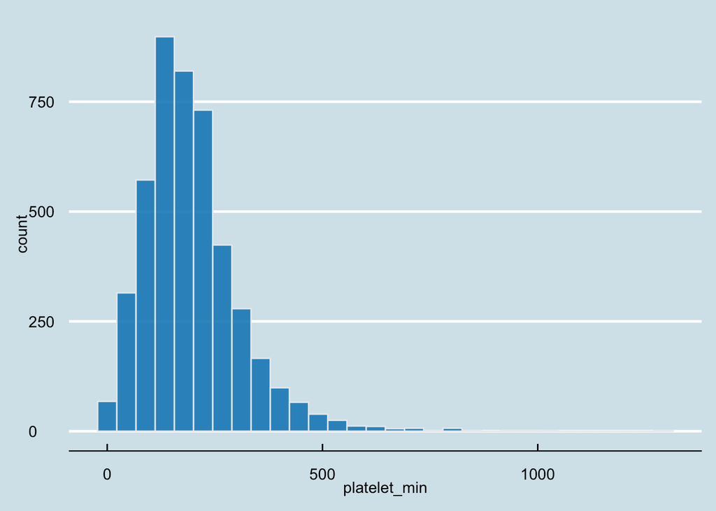

```r
ggplot(mimic_data, aes(x=platelet_min)) +
  geom_histogram( color="#e9ecef", fill="#188bc2", alpha=0.9, position = 'identity') +
  theme_economist(base_family="ITC Officina Sans")
```

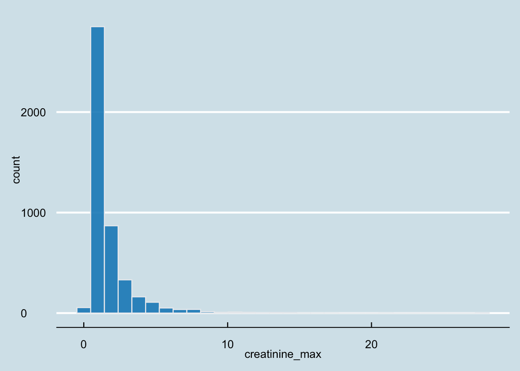

```r
ggplot(mimic_data, aes(x=creatinine_max)) +
  geom_histogram( color="#e9ecef", fill="#188bc2", alpha=0.9, position = 'identity') +
  theme_economist(base_family="ITC Officina Sans")
```

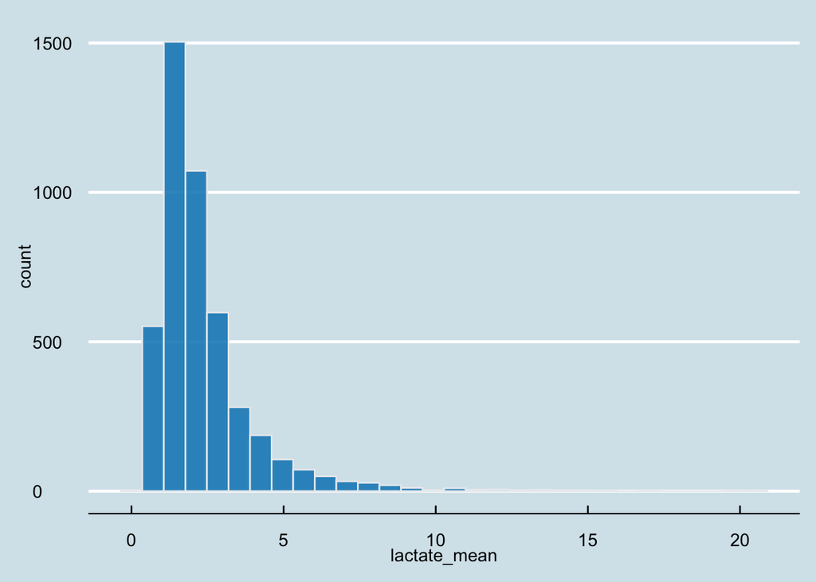

```r
ggplot(mimic_data, aes(x=lactate_mean)) +
  geom_histogram( color="#e9ecef", fill="#188bc2", alpha=0.9, position = 'identity') +
  theme_economist(base_family="ITC Officina Sans")
```